# Lecture 6: Functions

Data Analysis for Psychology in R 1

Tom Booth

Click for slides

## Today

- What are functions?
  - How do we use them?
  - How do we visualize them?

## Learning objectives

- Understand the basic principles of functions.
- Be able to calculate functions by hand and in R
- Be able to visualize functions
- Begin a appreciation of their usefulness for statistics

## What is a function?

- A function maps one set of values to some other set of values.
- Put differently, a function takes an input, does something, and provides an output.

$$x = \begin{bmatrix}
1 \\
2 \\
3 \\
\end{bmatrix}$$

$$f(x) = x-2$$

$$f(x) = \sqrt{x}$$

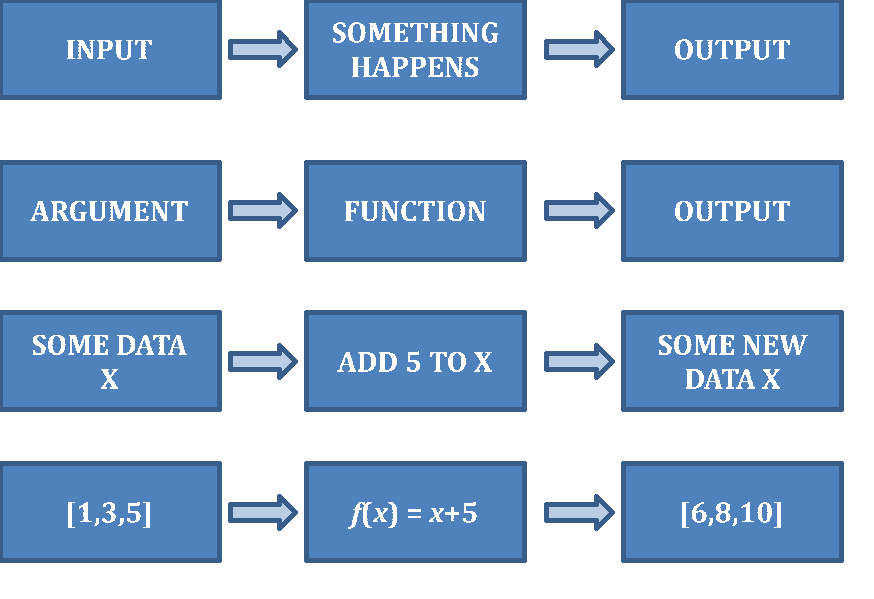

## Visualising Simple Functions

- An important tool in understanding functions is to plot them.
  - This helps us both understand plots
  - And gain intuition about functions.
- So let’s look at the following:

$$f(x) = 10 + 2x$$

- Where $x$ is:

$$x = \begin{bmatrix}
1 \\
2 \\
3 \\
4 \\
5 \\
6 \\
7 \\
8 \\
\end{bmatrix}$$

## Pre vs Post

- Let’s do this on the board
- Post lecture there will be a version of the slides with all this in.

## Briefly: Functions and R?

- As an aside, we see this logic in R.

```r
## in general
function([some data], do some things)
```

## Multiple arguments

- Functions can take multiple arguments. Consider:

$$f(x,y) = 10 + (x*y)$$
- Where:

$$x = \begin{bmatrix}
1 \\
2 \\
3 \\
\end{bmatrix}$$

$$y = \begin{bmatrix}
1 \\
2 \\
3 \\
\end{bmatrix}$$

| x | y |
| --- | --- |
| 1 | 1 |
| 1 | 2 |
| 1 | 3 |
| 2 | 1 |
| 2 | 2 |
| 2 | 3 |
| 3 | 1 |
| 3 | 2 |
| 3 | 3 |

| x | y | f(x,y) |
| --- | --- | --- |
| 1 | 1 | 11 |
| 1 | 2 | 12 |
| 1 | 3 | 13 |
| 2 | 1 | 12 |
| 2 | 2 | 14 |
| 2 | 3 | 16 |
| 3 | 1 | 13 |
| 3 | 2 | 16 |
| 3 | 3 | 19 |

## Why are functions important?

- There are going to be lots of examples of functions in action.
- Two primary examples are:
  - **Data transformations**
  - **Describing formal models**
- We will be using both of these frequently from now on.
- But let’s take a look at transformations (models next lecture)

## Transformations

- You already know lots of these:
  - Centimetres to metres
  - Kilograms to pounds
- But there are some common transforms we use in statistics:
  - Scaling (like the examples above)
  - Centering - making a new 0 point
  - Non-linear transformations (Square, square root, log, exponentials)

## Why do we use transformations?

- Scaling/Centering:
  - Almost always about interpretation.
  - Often used to provide common scale (e.g. z-scores, see normal distribution)
- Non-linear transforms:
  - These change the shape of a distribution…

## Non-linear transforms

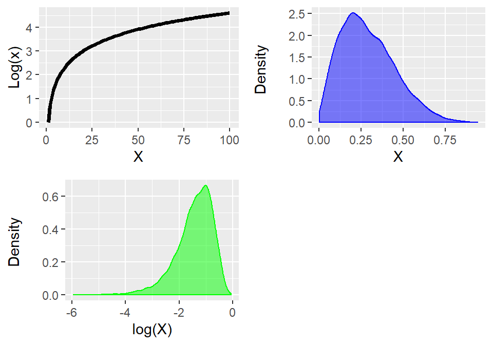

## Tasks for this week…

1. Finish any existing tasks from lab 5.
2. Reading: Chapter on LEARN written by Alex Doumas for our textbook.
3. Quiz 6: Central tendency, variability and R
   - Live now.
   - Close Sunday at 17:00

## Recommendations of the week

- Podcast: [No such thing as a fish](https://www.nosuchthingasafish.com/)
- Recipe: [Home made protein balls](https://www.myfoodandhappiness.com/the-perfect-protein-energy-balls/)
- Book: 12 Maps that Changed the World, Jerry Brotton
- Thing to do: [Water of Leith Walk](http://www.waterofleith.org.uk/)
- Coffee/food Place: Sausage roll guy (Meadows)